# Phylogenetic Tree Inspection and Rooting

Julie Cardon

2024-04-23

# Goals

1. Load the fastree unrooted tree.
2. Add tree to phyloseq object.
3. Visualize and inspect tree with ggtree.
4. Prune ASVs, if needed.
5. Root our tree.
6. Combine new tree with a phyloseq object.
7. Save 2 phyloseq objects: 1. Unrooted tree phyloseq object, 2. Rooted tree phyloseq object.

# Before you start

## Set my seed

```r
# Any number can be chosen
set.seed(238428)
```

## Load Packages

```r
pacman::p_load(tidyverse, phyloseq, ggtree, phytools,
               install = FALSE)
```

## Load Data files

```r
# Preprocessed phyloseq object
load("data/02_PreProcessing/raw_preprocessed_physeq.RData")
raw_preprocessed_physeq
```

```
## phyloseq-class experiment-level object
## otu_table()   OTU Table:         [ 64993 taxa and 168 samples ]
## sample_data() Sample Data:       [ 168 samples by 14 sample variables ]
## tax_table()   Taxonomy Table:    [ 64993 taxa by 9 taxonomic ranks ]
```

```r
# Load in the tree!
unrooted_tree <- read.tree("data/03_Phylogenetic_Tree/ASVs_unrooted.tree")
unrooted_tree
```

```
##
## Phylogenetic tree with 64993 tips and 64991 internal nodes.
##
## Tip labels:
##   ASV_33984, ASV_40577, ASV_3007, ASV_18731, ASV_26244, ASV_24024, ...
## Node labels:
##   , 0.631, 0.885, 0.901, 1.000, 0.649, ...
##
## Unrooted; includes branch lengths.
```

```r
str(unrooted_tree)
```

```
## List of 5
##  $ edge       : int [1:129983, 1:2] 64994 64995 64996 64997 64998 64998 64999 65000 65000 65001 ...
##  $ edge.length: num [1:129983] 0.0103 0.0145 0.0508 0.2103 0.1224 ...
##  $ Nnode      : int 64991
##  $ node.label : chr [1:64991] "" "0.631" "0.885" "0.901" ...
##  $ tip.label  : chr [1:64993] "ASV_33984" "ASV_40577" "ASV_3007" "ASV_18731" ...
##  - attr(*, "class")= chr "phylo"
##  - attr(*, "order")= chr "cladewise"
```

# Merge Phyloseq

```r
# Intuition check
stopifnot(ntaxa(raw_preprocessed_physeq) == ntaxa(unrooted_tree))

# Merge the tree with the phyloseq object
unrooted_physeq <-
  merge_phyloseq(raw_preprocessed_physeq, unrooted_tree)
```

[output not shown]

[output not shown]

[output not shown]

[output not shown]

[output not shown]

[output not shown]

[output not shown]

[output not shown]

[output not shown]

[output not shown]

[output not shown]

[output not shown]

[output not shown]

[output not shown]

```r
unrooted_physeq
```

```
## phyloseq-class experiment-level object
## otu_table()   OTU Table:         [ 64993 taxa and 168 samples ]
## sample_data() Sample Data:       [ 168 samples by 14 sample variables ]
## tax_table()   Taxonomy Table:    [ 64993 taxa by 9 taxonomic ranks ]
## phy_tree()    Phylogenetic Tree: [ 64993 tips and 64991 internal nodes ]
```

# Plot Tree with `ggtree`

[output not shown]

[output not shown]

[output not shown]

[output not shown]

[output not shown]

[output not shown]

[output not shown]

[output not shown]

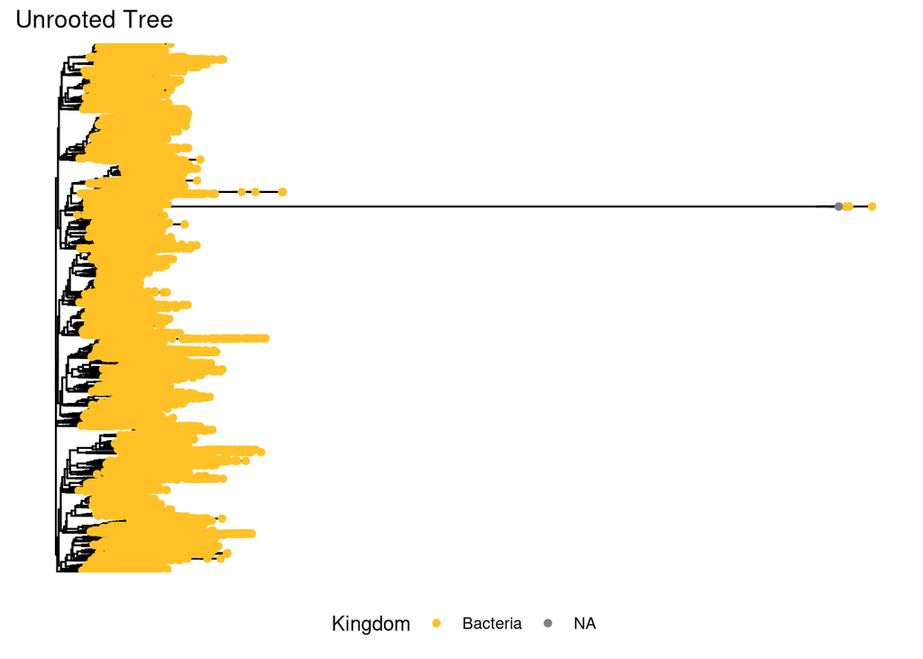

```r
# Make a basic tree
kingdom_tree <-
  ggtree(unrooted_physeq) +
  # color tips by kingdom
  geom_tippoint(mapping = aes(color = Kingdom)) +
  scale_color_manual(values = c("goldenrod1", "cornflowerblue", "grey")) +
  # Add title
  labs(title = "Unrooted Tree") +
  #move the legend to the bottom
  theme(legend.position = "bottom"); kingdom_tree
```

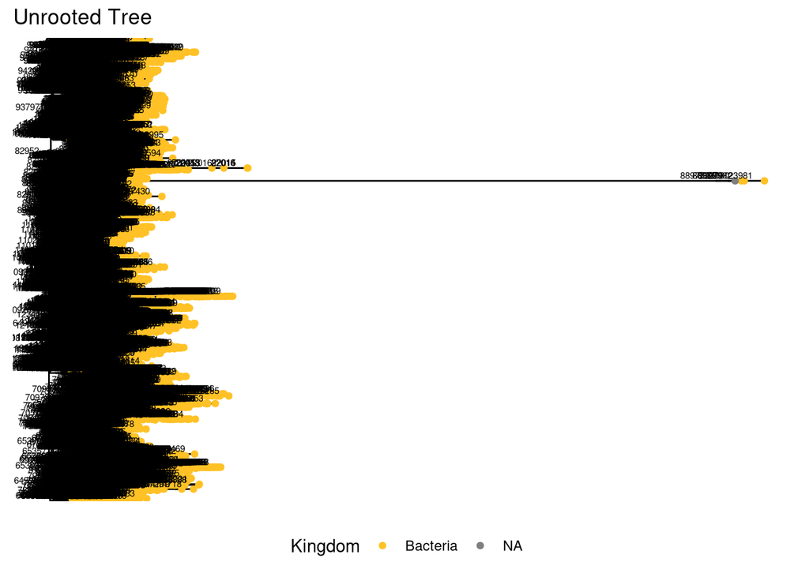

```r
kingdom_node_tree <-
  kingdom_tree +
  # Add the node label
  geom_text(aes(label=node), hjust= 1.5, vjust = -0.3, size = 2)
kingdom_node_tree
```

# Evaluate Long Branch

This part gets a bit manual

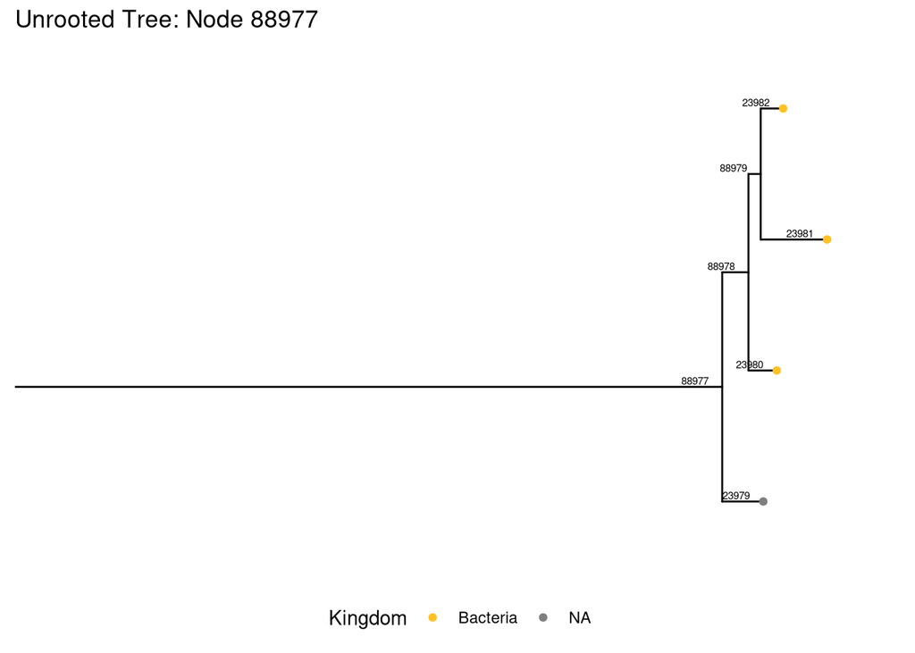

```r
# View a specific clade
# Zoom in on origin tree: Node 88977

# Zoom in on origin tree: Node 88977
viewClade(kingdom_node_tree +
          labs(title = "Unrooted Tree: Node 88977"),
          node = 88977)
```

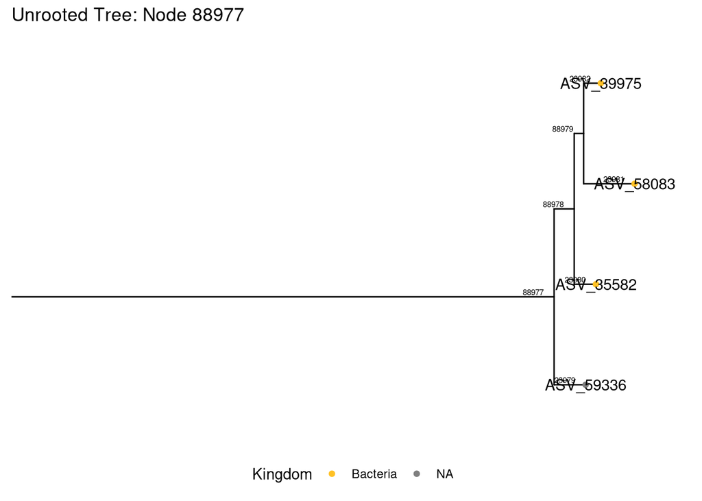

```r
viewClade(kingdom_node_tree +
          labs(title = "Unrooted Tree: Node 88977") +
          geom_text(aes(label=ASV)),
          node = 88977)
```

4 ASVs are suspect. Let’s explore these ASVs more!

```r
# Let's make a note of the the taxonomy and the ASV Sequence....
sus_ASVs <- c("ASV_39975", "ASV_58083", "ASV_35582", "ASV_59336")

unrooted_physeq %>%
  subset_taxa(., ASV %in% sus_ASVs) %>%
  tax_table() %>%
  data.frame()
```

[output not shown]

[output not shown]

[output not shown]

[output not shown]

[output not shown]

[output not shown]

[output not shown]

[output not shown]

```
##            Kingdom Phylum Class Order Family Genus Species       ASV
## ASV_59336     <NA>   <NA>  <NA>  <NA>   <NA>  <NA>    <NA> ASV_59336
## ASV_35582 Bacteria   <NA>  <NA>  <NA>   <NA>  <NA>    <NA> ASV_35582
## ASV_58083 Bacteria   <NA>  <NA>  <NA>   <NA>  <NA>    <NA> ASV_58083
## ASV_39975 Bacteria   <NA>  <NA>  <NA>   <NA>  <NA>    <NA> ASV_39975
##                                                                                                                                                                                                                                                                                                          …
## ASV_59336 ATCCTGTTTGCTCCCCACGCTTTCGCGCCTCAGCGTCAGTCTCGACCCAGGTCGCCGCCT…
## ASV_35582  ATCCTGTTTGCTCCCCACGCTTTCGCACCTGAGCGTCAGTCTTTGTCCAGGGGGCCGCCT…
## ASV_58083  ATCCTGTTTGCTCCCCACGCTTTCGCACCTCAGCGTCAATACATGTCCAGTGAGTCGCCT…
## ASV_39975  CTCCTGTTTGCTCCCCACGCTTTCGCACCTCAGTGTCAGTATCAGTCCAGGTGGTCGCCT…
```

```r
# Let's also check the counts of the ASV
unrooted_physeq %>%
  subset_taxa(., ASV %in% sus_ASVs) %>%
  otu_table() %>%
  data.frame() %>%
  colSums()
```

[output not shown]

[output not shown]

[output not shown]

[output not shown]

[output not shown]

[output not shown]

[output not shown]

```
##     B4_2022     G2_2022    G10_2022    G18_2022    G26_2022    G34_2022
##           0           0           0           0           0           0
##     V2_2022     B5_2022     G3_2022    G11_2022    G19_2022    G27_2022
##           0           0           0           0           0           0
##    G35_2022     V3_2022     B6_2022     G4_2022    G12_2022    G20_2022
##           0           0           0           0           0           0
##    G28_2022     M1_2022     V4_2022     B7_2022     G5_2022    G13_2022
##           0           0           0           0           0           3
##    G21_2022    G29_2022     M2_2022     V5_2022     B8_2022     G6_2022
##           0           0           0           0           0           0
##    G14_2022    G22_2022    G30_2022     M3_2022     S1_2022     B1_2022
##           0           0           0           0           0           0
##     B9_2022     G7_2022    G15_2022    G23_2022    G31_2022     M4_2022
##           0           0           0           0           3           0
##     S2_2022     B2_2022    B10_2022     G8_2022    G16_2022    G24_2022
##           0           0           0           0           0           0
##    G32_2022     M5_2022     S3_2022     B3_2022     G1_2022     G9_2022
##           0           0           0           0           0           0
##    G17_2022    G25_2022    G33_2022     V1_2022     S4_2022    N1B_2023
##           0           0           0           0           0           0
##    N2B_2023    N3B_2023    N4B_2023    N5B_2023    P1B_2023    P2B_2023
##           0           0           0           0           0           0
##    P4B_2023    P5B_2023    L1B_2023    L2B_2023    L3B_2023    L4B_2023
##           0           0           0           0           0           0
##    L5B_2023    V1B_2023    V2B_2023    V3B_2023    V4B_2023    V5B_2023
##           0           0           0           0           0           2
##   G36B_2023   G37B_2023   G38B_2023   G39B_2023   G40B_2023    S1B_2023
##           0           0           0           0           0           0
##    S2B_2023    S3B_2023    S4B_2023    S5B_2023  X3B1B_2023  X3B2B_2023
##           0           0           0           0           0           0
##  X3B3B_2023  X3B4B_2023  X3B5B_2023  X3B6B_2023  X3B7B_2023  X3B8B_2023
##           0           0           0           0           0           0
##  X3B9B_2023 X3B10B_2023  X3G1B_2023  X3G2B_2023  X3G3B_2023  X3G4B_2023
##           0           0           0           0           0           0
##  X3G5B_2023  X3G6B_2023  X3G7B_2023  X3G8B_2023  X3G9B_2023 X3G10B_2023
##           0           0           0           0           0           0
## X3G11B_2023 X3G12B_2023 X3G13B_2023 X3G14B_2023 X3G15B_2023 X3G16B_2023
##           0           0           0           0           0           0
## X3G17B_2023 X3G18B_2023 X3G19B_2023 X3G20B_2023 X3G21B_2023 X3G22B_2023
##           0           0           0           0           0           0
## X3G23B_2023 X3G24B_2023 X3G25B_2023 X3G26B_2023 X3G27B_2023 X3G28B_2023
##           0           0           0           0           0           0
## X3G29B_2023 X3G30B_2023 X3G31B_2023 X3G32B_2023 X3G33B_2023 X3G34B_2023
##           2           0           0           0           0           0
## X3G35B_2023  X3M1B_2023  X3M2B_2023  X3M3B_2023  X3M4B_2023  X3M5B_2023
##           0           0           0           0           0           0
##  X3N1B_2023  X3N2B_2023  X3N3B_2023  X3N4B_2023  X3N5B_2023  X3P1B_2023
##           0           0           0           0           0           0
##  X3P2B_2023  X3P3B_2023  X3P4B_2023  X3P5B_2023  X3L1B_2023  X3L2B_2023
##           0           0           0           0           0           0
##  X3L3B_2023  X3L4B_2023  X3L5B_2023  X3V1B_2023  X3V2B_2023  X3V3B_2023
##           0           0           0           0           0           0
##  X3V4B_2023  X3V5B_2023 X3G36B_2023 X3G37B_2023 X3G38B_2023 X3G39B_2023
##           0           0           0           0           0           0
## X3G40B_2023  X3S1B_2023  X3S2B_2023  X3S3B_2023  X3S4B_2023  X3S5B_2023
##           0           0           0           0           0           0
```

Let’s BLAST it on NSCBI Nucleotide Blast

ASV_58083 matches with: Uncultured bacterium clone IZ1RPV403DDB2F 16S ribosomal RNA gene, partial sequence with max and total score of 654, and 100% query cover, and E value of 0.0 and 94.43% Identity, and accession number KP945559.1

ASV_39975 matches with: Select seq MT626826.1 Pseudomonas sp. strain SeaQual_P_B791/7 16S ribosomal RNA gene, partial sequence Pseudomonas sp. total score of 785, 99% query cover, and E value of 0.0, and 100.00% Identity, and accession number 1387 MT626826.1

This whole clade looks suspicious because they are so far separated from the others and the contaminants need to be removed from the dataset. Let’s go ahead and do that…

# Prune the 4 suspect ASVs

```r
# Function from Joey McMurdie: https://github.com/joey711/phyloseq/issues/652
pop_taxa = function(physeq, badTaxa){
  allTaxa <-  taxa_names(physeq)
  allTaxa <- allTaxa[!(allTaxa %in% badTaxa)]
  return(prune_taxa(allTaxa, physeq))}

# Let's use the pop_taxa function :)
# Recreate a phyloseq object without ASV_456
unrooted_physeq_rm_sus_ASVs <-
  unrooted_physeq %>%
  pop_taxa(., sus_ASVs)
```

[output not shown]

[output not shown]

```r
# Intuition Check
ntaxa(unrooted_physeq) - ntaxa(unrooted_physeq_rm_sus_ASVs)
```

```
## [1] 4
```

[output not shown]

[output not shown]

[output not shown]

[output not shown]

[output not shown]

[output not shown]

[output not shown]

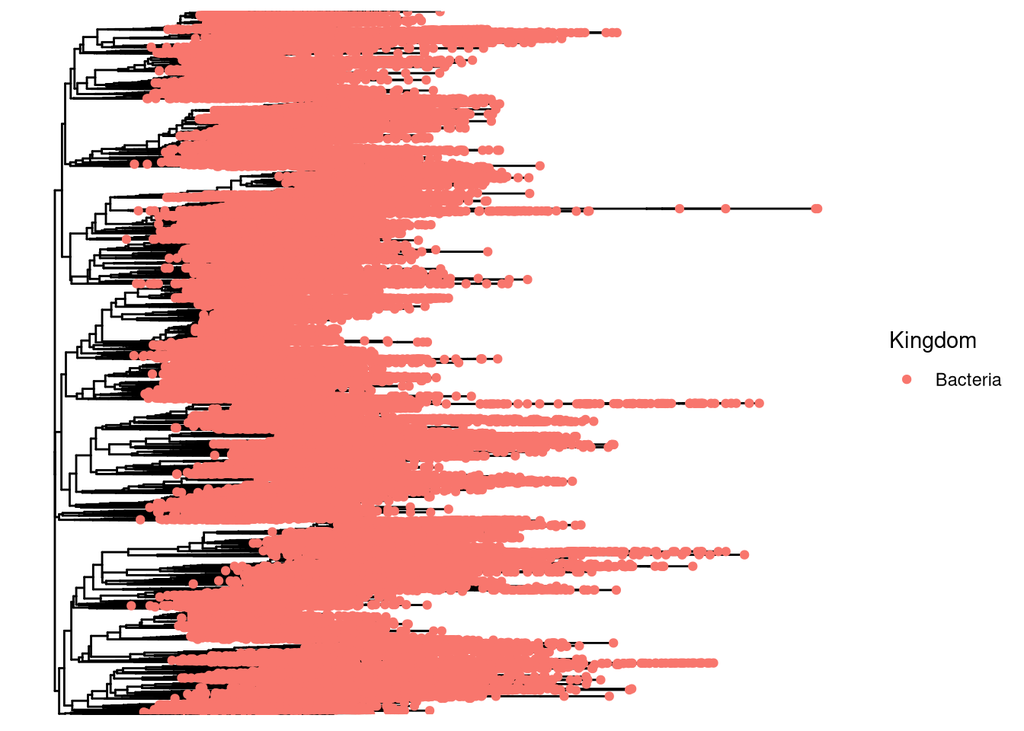

```r
# Visually inspect
ggtree(unrooted_physeq_rm_sus_ASVs) +
  geom_tippoint(mapping = aes(color = Kingdom))
```

# Midroot Tree

```r
# Is the tree rooted?
new_unrooted_tree <-phy_tree(unrooted_physeq_rm_sus_ASVs)
is.rooted(new_unrooted_tree)
```

```
## [1] FALSE
```

```r
# Let's midpoint root the tree
midpoint_rooted_tree <- midpoint.root(new_unrooted_tree)

# Is the new tree rooted?
is.rooted(midpoint_rooted_tree)
```

```
## [1] TRUE
```

```r
# Assign to a new phyloseq object: merging subsetted phyloseq with the new rooted tree

# 1. Create the phyloseq object without strange ASVs
physeq_rm_susASVs <-
  raw_preprocessed_physeq %>%
  subset_taxa(ASV != sus_ASVs)

# Merge tree with the new physeq_rm_susASVs
midroot_physeq_rm_susASVs <-
  merge_phyloseq(physeq_rm_susASVs, midpoint_rooted_tree)
```

[output not shown]

[output not shown]

[output not shown]

[output not shown]

[output not shown]

[output not shown]

[output not shown]

[output not shown]

```r
midroot_physeq_rm_susASVs
```

```
## phyloseq-class experiment-level object
## otu_table()   OTU Table:         [ 64989 taxa and 168 samples ]
## sample_data() Sample Data:       [ 168 samples by 14 sample variables ]
## tax_table()   Taxonomy Table:    [ 64989 taxa by 9 taxonomic ranks ]
## phy_tree()    Phylogenetic Tree: [ 64989 tips and 64988 internal nodes ]
```

[output not shown]

[output not shown]

[output not shown]

[output not shown]

[output not shown]

[output not shown]

[output not shown]

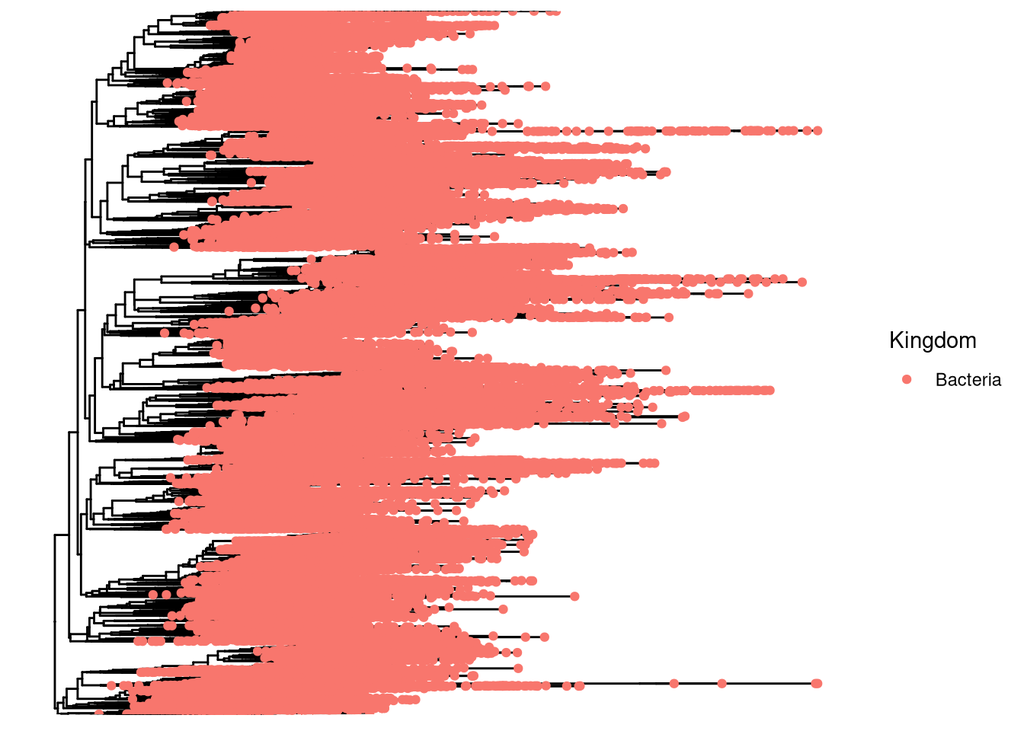

```r
# Quick inspection of tree
ggtree(midroot_physeq_rm_susASVs) +
  geom_tippoint(mapping = aes(color = Kingdom))
```

# Save to a new phyloseq object

```r
# Save both phyloseq objects with our tree object to one .RData file
save(list = c("unrooted_physeq_rm_sus_ASVs", "midroot_physeq_rm_susASVs"),
     file = "data/03_Phylogenetic_Tree/phytree_preprocessed_physeq.RData")
```